[figure not shown]

J Cell Physiol. 2020;235:5030–5040.

wileyonlinelibrary.com/journal/jcp

5030

|

© 2019 Wiley Periodicals, Inc.

Received: 10 June 2019 | Accepted: 3 September 2019

DOI: 10.1002/jcp.29401

R E V I E W A R T I C L E

Regulatory T cells for amyotrophic lateral sclerosis/motor

neuron disease: A clinical and preclinical systematic review

Misagh Rajabinejad<sup>1,2</sup>

| Sedigheh Ranjbar<sup>1,2</sup>

| Leila Afshar Hezarkhani<sup>3</sup>

|

Farhad Salari<sup>2</sup>

| Ali Gorgin Karaji<sup>2</sup>

| Alireza Rezaiemanesh<sup>2</sup>

1Student Research Committee, School of

Medicine, Kermanshah University of Medical

Sciences, Kermanshah, Iran

2Department of Immunology, School of

Medicine, Kermanshah University of Medical

Sciences, Kermanshah, Iran

3Department of Neurology,

School of Medicine, Farabi Hospital,

Kermanshah University of Medical Sciences,

Kermanshah, Iran

Correspondence

Alireza Rezaiemanesh, PhD, Department of

Immunology, School of Medicine, Kermanshah

University of Medical Sciences, Daneshgah

Street, Shahid Shiroudi Boulevard,

Kermanshah 6714869914, Iran.

Email: alireza.rezaiemanesh@kums.ac.ir

Abstract

Amyotrophic lateral sclerosis (ALS) is a neurodegenerative disorder characterized by

neuronal degeneration and inflammation in the nerves. The role of the immune

system has been concentrated by researchers in the etiopathogenesis of the disease.

Given the inhibitory roles of regulatory T cells (Tregs), it is expected that increasing

or activating their populations in patients with ALS can have significant therapeutic

effects. Here we searched databases, including CENTRAL, MEDLINE, CINAHL Plus,

clinicaltrials.gov, and ICTRP for randomized clinical trials (RCTs) and non‐RCTs until

March 2019. For preclinical studies, we searched PubMed, Scopus, and Google

Scholar up to June 2019. We also included preclinical studies, due to the lack of

clinical information available, which used Tregs (or directly targeting them) for

treating mice models of ALS. We identified 29 records (CENTRAL 7, MEDLINE 4,

CINAHL Plus 8, and clinicaltrials.gov 10) and removed 10 duplicated publications.

After screening, we identified one RCT which had been published as an abstract,

three non‐RCTs, and four ongoing studies. We also identified 551 records (PubMed

446, Google Scholar 68, and Scopus 37) for preclinical studies and performed a meta‐

analysis. Finally, we found three papers that matched our inclusion criteria for

preclinical studies. Results indicated the effectiveness of the application of Tregs in

the treatment of ALS. Our meta‐analysis on preclinical studies revealed that Tregs

significantly prolonged survival in mice models of ALS. Overall, our analysis testified

that exertion of Tregs in the treatment of ALS is a promising approach, that

notwithstanding, requires further evaluations.

K E Y W O R D S

amyotrophic lateral sclerosis, motor neuron disease, preclinical study, randomized controlled

trial, regulatory T cells

1

|

INTRODUCTION

Amyotrophic lateral sclerosis (ALS), also known as Lou Gehrig’s

and motor neuron disease (MND), is a fatal neurodegenerative

disease. This disorder is very heterogeneous and many of its

causes are still unknown. However, several factors involved in its

pathogenesis have been identified, including accumulation and

collapse of miss fold proteins, oxidative stress, defective axon

Abbreviations: AEs, adverse events; ALS, amyotrophic lateral sclerosis; ALSFRS‐R, ALS Functional Rating Scale‐Revised; ALSSQOL‐R, amyotrophic lateral sclerosis‐specific quality of life‐

Revised; CNS, central nervous system; CTLA4, cytotoxic T‐lymphocyte associated protein 4; FOXP3, forkhead box P3; FVC, forced vital capacity; IFN‐γ, interferon‐γ; IL, interleukin; RCT,

randomized controlled trial; ROS, reactive oxygen species; SAE, serious adverse event; sALS, sporadic amyotrophic lateral sclerosis; SD, standard deviation; SOD, superoxide dismutase.

transfer

function,

abnormal

activation

of

astrocyte,

neuron

inflammation, cytoskeletal protein abnormalities, mitochondrial

function impairment, and glutamate excitotoxicity (Moisse &

Strong, 2006; Van Dyke et al., 2016). ALS is characterized by the

destruction of the upper and lower neurons that begins in

adults. The disease begins with the weakening, of the hands and

feet in 70% of the patients and in 35% of the remaining patients

with a bulbar weakening which causes defective swallowing and

speaking. The degeneration of the neuronal motor leads to the loss

of respiratory muscles and the average death within 3–5 years

(Ajroud‐Driss & Siddique, 2015). Almost 90% of ALS cases are

sporadic (sALS) and do not have a family history of the condition.

The familial type of the disease is responsible for approximately

10% of all cases, and so far about 70–80% of the responsible genes

have

been

identified (containing

approximately

20

different

genes). Interestingly, mutations in some of these genes are also

observed in patients without a family history (Talbot, Feneberg,

Scaber, Thompson, & Turner, 2018).

Various studies clearly indicate that ALS is the result of

interactions between the environment and genetic abnormalities

(Beers & Appel, 2019; Zou et al., 2017). Advances in genetic studies

have led to the identification of many of the genes responsible for

this disease. Many proteins encoded by these mutated genes directly

or indirectly affect the function of the immune system, which is

important evidence of the role of immune system disorders in the

pathogenesis of ALS. Extensive inflammation in the central nervous

system (CNS) is observed in patients with mutations in superoxide

dismutase 1 (SOD1; the first identified the genetic cause of ALS), TAR

DNA binding protein (TARDBP), and chromosome 9 open reading frame

72 (C9orf72) genes. Several studies have also shown that mutations

in genes, including optineurin, sequestosome‐1 protein, TANK‐binding

kinase 1, valosin‐containing protein, tumor necrosis factor α‐induced

protein 3 interacting protein‐1, and chemokine receptor 1 may also

impair immune function and increase inflammation in patients or

experimental models of ALS. In addition, there are reports indicating

that autophagy, nuclear factor‐κB, and the nucleotide‐binding domain‐

like receptor protein 3 may involve in the pathogenic process of ALS by

altering the immune system function and inflammatory response

(Beers & Appel, 2019).

The global outbreak of the disease is ∼8 per 100,000 people

(Moisse & Strong, 2006). Studies about the environmental factors

that cause the ALS are still unconvincing, but a recent meta‐analysis

study shows that there are different patterns of genes responsible

for the disease in different geographic regions (Zou et al., 2017). In

this meta‐analysis, which included 111 different studies, a sig-

nificant difference was identified between European and Asian

patients regarding the frequencies of mutations in major genes

responsible for ALS. In European populations, the most common

mutations were found in C9orf72 (familial 33.7% and sporadic

5.1%), SOD1 (familial 14.8% and sporadic 1.2%), TARDBP (familial

4.2% and sporadic 0.8%), and FUS (familial 2.8% and sporadic 0.3%)

genes, while SOD1 (familial 30.0% and sporadic 1.5%), FUS (familial

6.4% and sporadic 0.9%), C9orf72 (familial 2.3% and sporadic 0.3%),

and TARDBP (familial 1.5% and sporadic 0.2%) were the most

common mutations in Asian populations.

1.1

|

Regulatory T cells in ALS

Both innate and adaptive immunity play an important and inter-

dependent role in the progression of ALS and the process of the

inflammation. The most important clinical finding at the site of

neuronal damage in ALS is neuronal inflammation, which is caused by

the activation of microglia (resident macrophage within the CNS),

astrocytes, and infiltration of monocytes and T cells (Zhao, Beers, &

Appel, 2013), and some reports suggest that reducing the rate of the

inflammatory response can delay the onset of the disease and

increase survival (A McCombe & D Henderson, 2011; Moisse &

Strong, 2006; Nguyen, D’Aigle, Gowing, Julien, & Rivest, 2004; Phani,

Re, & Przedborski, 2012).

In a normal CNS, resting microglia and regulatory T cells (Tregs)

provide immune surveillance in the neuronal environment (Lasiene &

Yamanaka, 2011; Moisse & Strong, 2006). In the early stages ALS, the

phenotype M2 of microglial cells have a major role and able to

secrete high levels of neurotrophins such as insulin‐like growth

factor‐1 and progranulin, which have a neuroprotective function.

Moreover, M2 microglial cells release anti‐inflammatory cytokines,

such as transforming growth factor‐β (TGF‐β), interleukin‐10 (IL‐10),

and interleukin‐1 receptor antagonists, which inhibit the proinflam-

matory response. Tregs also release anti‐inflammatory cytokines to

maintain the phenotype M2 of microglial cells. In addition, astrocytes

participate in this protective process by secreting neurotrophic

factors and taking extracellular glutamate. Astrocytes also increase

the

antioxidant

capacity

of

neurons

by

releasing

glutathione

precursors (CysGly), which are harvested by the neuronal engine.

Thus, in the early stages of ALS, microglia, and astrocytes can

maintain the survival of the neuronal engine. However, as the disease

progresses, the risk signals, including mSOD1, oxidized SOD1, and

ATP are released from the neurons. These factors induce the

activation of M1 microglia via CD14/toll‐like receptors, scavenger

receptors, and purinergic P2 receptors. The result of the downstream

signaling of these receptors in the production of proinflammatory

cytokines, such as IL‐1β and tumor necrosis factor‐α (TNF‐α) and

enhanced neurotoxicity through the release of the free radicals. In

addition, M1 microglia cells activate astrocytes via reactive oxygen

species (ROS) and proinflammatory cytokines. Activated astrocytes

contribute to the generation of the harmful inflammatory phenotype

by releasing ROS and proinflammatory cytokines, which induces

more activation of the microglia. In addition, activated astrocytes and

neurons produce C–C motif chemokine ligand 2 that recruits

peripheral

monocytes/macrophages

into

CNS

and

exacerbates

neuronal degeneration (Lasiene & Yamanaka, 2011; Moisse & Strong,

2006; Zhao et al., 2013). Overall, the primary immune response to

damaged nerves helps repair tissues, which is due to the presence of

Tregs and their effects on the differentiation of M2 microglia. As the

disease progresses, immune responses from M2 microglia and Tregs

shift to M1 microglia and T helper (Th) 1/Th17 cells and this causes

RAJABINEJAD ET AL.

|

5031

more inflammation and damage to the neurons (Zhao et al., 2013;

Figure 1).

Tregs are a population of CD4<sup>+</sup>cells, which are known as

FOXP3<sup>+</sup>CD25<sup>high</sup>CD127<sup>−</sup><sup>/low</sup>CTLA‐4<sup>+</sup>GITR<sup>+</sup>CD45RA<sup>+</sup>

(CD45RA<sup>−</sup>CD45RO<sup>+</sup>in memory and effector Tregs; Azimi et al.,

2016). These cells are divided into two subgroups, including

forkhead box P3<sup>+</sup>(FOXP3<sup>+</sup>) natural Tregs (nTregs) and FOXP3<sup>−</sup>‐

induced Tregs (iTregs). nTregs originate from thymocytes located

in the thymus (primary lymphoid organ) due to agonist selection,

and iTregs (Tr1 and Th3) are derived from peripheral T cells in the

presence of TGF‐β, or IL‐10, and retinoic acid in the secondary

lymphoid organs or mucosa‐associated lymphoid tissue (Mohr,

Malhotra, Mayer, Gorochov, & Miyara, 2018). These cells are the

main reservoirs of maintaining peripheral tolerance by secreting

anti‐inflammatory cytokines, such as IL‐10, IL‐35, IL‐4, and TGF‐β,

expressing

inhibitory

receptors

like

cytotoxic

T‐lymphocyte

associated protein 4 (CTLA‐4) and up taking IL‐2 through CD25.

Studies on mouse models of ALS showed that the deletion of

TCD4<sup>+</sup>cells accelerated the disease progression, and the presence

of TCD4<sup>+</sup>cells reduced the level of proinflammatory cytokines.

This study also found that activated CD4<sup>+</sup>CD25<sup>+</sup>cells prolonged

the life span of SOD1 mutant mice (Lasiene & Yamanaka, 2011).

Other investigations show that CD4<sup>+</sup>CD25<sup>hi</sup>FOXP3<sup>+</sup>cells are

increased in the early stages of disease progression and decreased

during the rapid phase of disease progression, which is probably

due to the reduction of FOXP3 expression in Tregs. In addition, a

recent study in ALS mice shows that Tregs inhibit microglia cells

through an IL‐4 dependent mechanism. Furthermore, Tregs in the

slow phase

of

ALS

increase

the

level

of

anti‐inflammatory

cytokines and suppress T cells with IL‐4, IL‐10, and TGF‐β (Zhao,

Beers, Liao, Henkel, & Appel, 2012).

Studies in the patients with ALS also show a similar pattern compared

with studies in the mouse models, and it has been observed that Tregs

are significantly decreased with progression of the disease (Table 1) and

gradually lose their regulatory functions (Bargh et al., 2018; Henkel et al.,

2013; Menon et al., 2014; Sheean et al., 2018). Recently, in a cohort study

performed on 33 patients and 38 healthy controls, it was shown that the

progression rate of ALS in patients was inversely correlated with total

Treg count, although naive Tregs (CD45RA<sup>+</sup>) were not correlated with

the rate of disease progression (Sheean et al., 2018). They also used

transgenic SOD1<sup>G93A</sup>mice models to confirm their study results in

humans. The study showed that if these mice were treated with IL‐2

monoclonal antibody complexes (IL‐2c), the amount of effector Treg

population (CD45RA<sup>−</sup>CD45RO<sup>+</sup>) was significantly increased, and the

inflammation of the neurons and the progression of the disease would be

reduced. In addition, another study, which was accomplished in 2018 on

37 patients with ALS and 30 healthy controls, also confirmed the results

of the previous study on reducing regulatory cells with disease

progression. This study reported a significantly higher proportion of

CD4<sup>+</sup>T cells, along with a significantly lower proportion of CD4<sup>+</sup>CD25<sup>+</sup>

Tregs, in the peripheral blood of patients with ALS compared with the

control group (Bargh et al., 2018).

In addition to studies that show a decrease in the number of

Tregs during the disease progression, there are also studies

indicating that they are functionally defective (Alsuliman et al.,

2016; Beers et al., 2017). These studies have shown that Tregs

from patients with ALS failed to suppress T‐cell proliferation and

cytokine production (including interferon‐γ [IFN‐γ], TNF‐α, and

IL‐2). In one of these studies, it was shown that circulating Tregs

in patients with ALS had less suppressive activity than that of the

control group (Beers et al., 2017). Despite the fact that this

suppressive dysfunction was observed in both slowly and rapidly

progressing patients with ALS, the severity of this dysfunction

was higher in rapidly progressing patients with ALS than in slowly

progressing patients with ALS. In addition, rapidly progressing

patients had also less FOXP3 messenger RNA (mRNA) expression

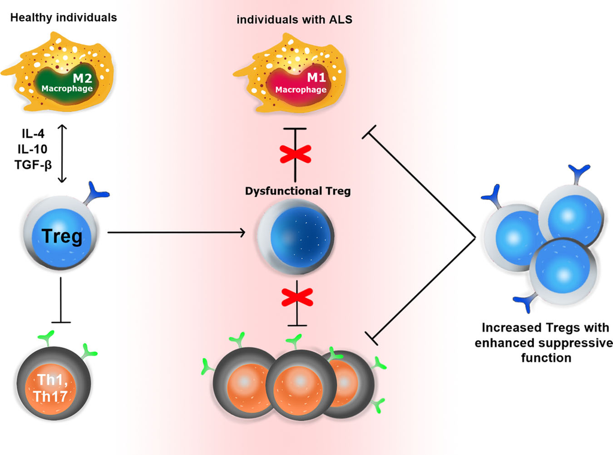

FIGURE 1

Hypothetical model of Tregs

function in ALS. ALS, amyotrophic

lateral sclerosis; IL, interleukin;

TGF‐β, transforming growth

factor‐β; Tregs, regulatory T cells

5032

|

RAJABINEJAD ET AL.

than slowly progressing patients and healthy controls. This study

also showed that the suppressive function of Tregs from patients

with ALS could be restored. After in vitro expansion, Tregs from

patients with ALS were able to regain their suppressive potency

and reach the level of Treg cells from the control group. The

results of this study showed that the future of the autologous

transfer of Tregs could be promising in treating the ALS.

Consequently, according to the results of studies in both

human and mouse models, it can be expected that Tregs will be an

important therapeutic target for patients with ALS. Moreover, it is

expected that by increasing their population in patients or

targeting them with drugs, Tregs can have positive therapeutic

outcomes in patients. For this reason, we decided to systematically

summarize the results of studies that used Tregs (or directly

targeting them) for the treatment of patients with ALS. The aim of

this study is to provide acceptable preclinical or clinical evidence

of the usefulness of Tregs (as disease‐modifying agent) for the

treatment of the patients with ALS and help to understand

whether

the

data

of

experimental

studies

implying

to

the

beneficial effects of Tregs in the treatment of ALS are reliable.

1.2

|

Description of the intervention

An increased number of Tregs in the body can be due to different

pharmacological drugs or even autologous transplantation of these

cells. In this review, all of the drugs that directly increase the Tregs

population or their activation in patients were investigated. These

factors may include cytokines, transcription factors, biological drugs

(antibodies), or immunomodulatory drugs.

2

|

OBJECTIVES

We set out to review the evidence from randomized clinical trials

(RCTs) and non‐RCTs and in vivo preclinical studies for the efficacy of

Tregs in the treatment of ALS disease.

3

| METHODS

3.1

|

Inclusion criteria

3.1.1

|

Types of studies

All controlled clinical trials that are double‐blind RCTs and used

Tregs (or directly targeting them) for treating patients with ALS were

included in our review. Studies that are randomized controlled trials

but they clearly do not indicate which method they use, were

referred in our study. After the initial searches, because of the

question of interest cannot be answered only by RCTs, we decided to

also review non‐RCTs and discussed the clinical results in two RCTs

and non‐RCTs. Our strategy for non‐RCTs was to include the best

available studies that can answer to our study question. In addition,

due to the risk of bias, we would prefer to include studies that were

double or triple‐blind and used the masking methods in the study; but

if sufficient results from blind studies were not available, also open‐

labeled studies were included in our review. In addition, we decided

to include in vivo preclinical studies, due to the lack of clinical

information available, which used Tregs (or directly targeting them)

for treating mice models of ALS and discussed them in the preclinical

result section.

3.1.2

|

Types of participants

Eligible studies had to include participants of any age or sex with ALS

having all of the following clinical criteria.

• Diagnosis of ALS according to the criteria for the disease diagnosis,

known as the El Escorial World Federation of Neurology criteria

(also known as Airlie House criteria; Brooks, 1994; Brooks, Miller,

Swash, & Munsat, 2000). Additional tests may include electro-

myogram, magnetic resonance imaging, lumbar puncture, muscle

biopsy, and blood and urine tests.

• Diagnosis of ALS with the onset of less than or equal to 5 years

from the first onset of clinical symptoms. Unfortunately, most of

the patients with ALS die from respiratory failure, usually within

TABLE 1

Studies demonstrating a decrease in the number of Tregs with disease progression

Study

Year

Number of

patients

Number of

healthy control

ALSFRS‐R score

Disease duration at

the time of studies

Decrease in the number of Tregs

compared with healthy control

(Mean ± SD)

(Mean ± SD)

(p value)

Sheean et al.

2018

33

38

43

14 month

p = .01

(CD45<sup>+</sup>Tregs)

Bargh et al.

2018

37

30

34.6 ± 8.1

27.7 ± 16.3 month

p = .02

(Total Tregs)

Menon et al.

2014

38

40

NA

NA

p = .036

(CD45<sup>+</sup>Tregs)

Henkel et al.

2013

54

33

NA

NA

p = .003

(Total Tregs in rapidly progressing

patients)

Abbreviations: ALS, amyotrophic lateral sclerosis; ALSFRS‐R, ALS Functional Rating Scale‐Revised; NA, not applicable; SD, standard deviation; Tregs,

regulatory T cell.

RAJABINEJAD ET AL.

|

5033

3–5 years from when the symptoms first appear, and only 14% of

patients with ALS survive 5 years or more (Mateen, Carone, &

Sorenson, 2010). For this reason, people who live more than 5

years after first clinical symptoms are generally in advanced and

severe conditions and many of the indicators and markers in their

bodies are probably changed due to severe disorders. In addition,

many studies in the field of ALS are aimed at finding a cure for

increasing survival and preventing disease progression in newly

diagnosed patients.

• Forced vital capacity (FVC) ≥65% of that predicted for age and

height. FVC is an index of respiratory function that can be an

important predictor of survival in patients with ALS. Studies have

shown

that

patients

with

FVC < 70%

had

a

faster

disease

progression with an average survival of 2.91 years, compared

with 4.08 years for patients with FVC > 70% (Czaplinski, Yen, &

Appel, 2006). For this reason, we preferred the studies which had

patients with FVC ≥ 65%.

• Not taking riluzole (a common drug in the treatment of the

patients with ALS) or on a stable dose if undergoing treatment with

this agent.

• Without medical disorders, such as autoimmunity, primary or

secondary immunodeficiency, malignancy, allergy, acute or chronic

infections, and history of transplantation or use of immune‐

suppressive drugs.

For preclinical studies, our inclusion criteria were as follows:

• Studies on mice models of ALS (mSOD1<sup>G93A</sup>) that exerted Tregs

(or any drugs directly targeting Tregs) for treatment.

• Studies with starting treatment after the onset of symptoms.

• Studies with assessment of outcomes compared with a control

group (untreated transgenic mice).

3.1.3

|

Types of outcome measures

Primary clinical outcomes

1. Treatment‐related

change

in

the

percentage

of

Tregs

(CD4<sup>+</sup>CD25<sup>+</sup>FOXP3<sup>+</sup>) assessed by multicolor flow cytometry or

gene expression methods. It can also include FOXP3<sup>−</sup>Tregs (Th3

and Tr1) as well as markers identifying subtypes (like CD45RA

and CD45RO).

Secondary clinical outcomes

1. Treatment‐related

change

in

levels

of

blood

inflammatory

biomarkers (including TNF‐α, IFN‐γ, IL‐1, IL‐6, etc.) or in levels

of blood anti‐inflammatory biomarkers (including IL‐10, TGF‐β,

etc).

2. Treatment‐related change in score of ALS Functional Rating

Scale‐Revised (ALSFRS‐R).

Progress and severity of the ALS are determined by physicians

using ALSFRS‐R (Cedarbaum et al., 1999). This test consists of 12

questions that are scored from 0 to 4 per question, depending on

the patient’s condition (0 indicates the worst condition [no ability]

and 4 indicates the best condition [normal ability]). ALSFRS‐R

measures speech, salivation, swallowing, handwriting, cutting food

and handling utensils, dressing and hygiene, turning in bed and

adjusting bedclothes, walking, climbing stairs, dyspnea, orthopnea,

and respiratory insufficiency.

3. Change in quality of life.

Treatment‐related change in ALS Specific Quality of Life‐Revised

(ALSSQOL‐R). The ALSSQOL‐R is a specific test with 50 questions

(46 of the questions are used in scoring) that is completed by the

patients with ALS. Each question is rated by the patient using a

0–10 point (0 indicates the worst condition and 10 indicates the

best condition; Simmons et al., 2010).

4. A number of participants with treatment‐related serious adverse

events (SAEs), which is defined as any unwanted medical

occurrence that results in death (at any dose) or hospitalization.

For preclinical studies, outcomes include:

1. Treatment‐related

change

in

the

percentage

of

Tregs

(as

described in primary clinical outcome).

2. Treatment‐related change in the levels of blood inflammatory

biomarkers.

3. Treatment‐related change in survival.

3.2

|

Electronic searches

For clinical trials, we searched the Cochrane Central Register of

Controlled Trials (CENTRAL; 2019, Issue 3 of 10) in the Cochrane

Library (12 March 2019), MEDLINE (January 1966–March 2019),

Cumulative Index to Nursing and Allied Health Literature plus

(CINAHL; January 1982–March 2019), www.clinicaltrials.gov and the

World Health Organization International Clinical Trials Registry

Platform

(ICTRP;

www.who.int/ictrp/en/),

and

as

well

as

the

reference lists of review publications. For the preclinical studies,

we searched PubMed, Scopus, and Google Scholar until June 28,

2019. There was not any restriction on searching. We also tried to

get

more

information

by

contacting

the

authors

of

relevant

publications. The detailed search strategies for clinical trials are in

the appendices: MEDLINE (Appendix 1), CINHAL plus (Appendix 2),

CENTRAL (Appendix 3), clinicaltrials.gov (Appendix 4), and ICTRP

(Appendix 5).

3.3

|

Data collection and analysis

3.3.1

|

Selection of studies and data extraction

Two of the review authors (M. R. N. and A. R. M.) independently

reviewed all the records of the search and identified those that were

fully published and matched with our inclusion criteria. If there was a

5034

|

RAJABINEJAD ET AL.

discrepancy in the results and the decision to include or exclude a

study, we would solve it with discussion among the authors, and if

needed, we would contact the author to obtain further information.

3.3.2

|

Measures of treatment effect

Statistical analysis was performed on the preclinical trials using the

Cochrane software Review Manager v5.3 (RevMan v5.3). For

continuous variables, standardized mean difference and p value were

calculated based on the random‐effects model, with a corresponding

95% confidence interval (CI), according to mean, standard deviation

(SD), and the number of participants reported in papers. p < .05 were

considered to be statistically significant. We only performed meta‐

analyses for the outcomes that were similar enough to be meaningful,

and the mean, SD, and the number of participants in the study had

been clearly reported.

For clinical results that were not homogenous enough for meta‐

analyses, we used the Grading of Recommendations, Assessment,

Development, and Evaluation model (via GRADpro/GTD online

software) to access the quality of the evidence (Puhan et al., 2014).

We assessed the risk of bias of the included studies as described in

Chapter 8 (Assessing the risk of bias in included studies) of the

Cochrane Handbook for Systematic Reviews of Interventions (Higgins,

2011). In addition, we evaluated the statistical heterogeneity

between trials using both the Q‐test of heterogeneity and the I<sup>2</sup>

test of inconsistency. Any disagreements were resolved by discussion

among the review authors.

4

|

RESULTS

4.1

|

Preclinical results

After the initial searches, we identified 551 records (PubMed 446,

Google Scholar 68, and Scopus 37). After removing duplicates and

unrelated papers, we found three papers that matched our inclusion

criteria for in vivo preclinical studies (Beers et al., 2011; Sheean et al.,

2018; Vallarola et al., 2018). All three articles were conducted on

transgenic mSOD1<sup>G93A</sup>mice (ALS experimental model) and fulfilled

our inclusion criteria for preclinical studies.

Beers et al. study was conducted on mSOD1<sup>G93A</sup>and RAG2

knockout mice, C57BL/6 strain, and used age‐matched wild‐type

mice as controls. In this study, T cells were isolated from the spleen,

lymph nodes, and blood. CD4<sup>+</sup>T cells and Tregs were separated using

the magnetic‐activated cell sorting. Tregs were transferred into

mSOD1/RAG2<sup>−</sup><sup>/</sup><sup>−</sup>mice without ex vivo activation (at 70 days of age)

via tail vein injections and repeated every 28 days. The passive

transfer of Tregs significantly increased the mRNA expression levels

of IL‐4 (p = .025) and decreased the mRNA expression levels of IFN‐γ

(p = .026) in the spinal cords of 20‐week‐old mSOD1/RAG2<sup>−</sup><sup>/</sup><sup>−</sup>mice

compared

with

untreated

mSOD1

mice.

Furthermore,

passive

transfer of Tregs into mSOD1/RAG2<sup>−</sup><sup>/</sup><sup>−</sup>mice prolonged survival by

33 days (46%) compared with untreated mSOD1/RAG2<sup>−</sup><sup>/</sup><sup>−</sup>mice

(p < .01; Beers et al., 2011).

Sheean et al’s. (2018) study was conducted on mSOD1<sup>G93A</sup>mice

(C57BL/6 strain) and used age‐matched wild‐type mice as controls.

Mice were divided into three groups (IL‐2/IL‐2c [IL‐2 monoclonal

antibody complex] + rapamycin, rapamycin alone, and placebo [nor-

mal saline] alone). Mice in the first group were intraperitoneally

injected with 100 μl of IL‐2/IL‐2c + rapamycin once a day for 3 days

(at 60 days of age), followed by twice‐weekly injections. Treatment

with IL‐2c significantly increased the percentage of Tregs (p < .001)

and the mRNA expression level of Foxp3 (p = .003) in SOD1<sup>G93A</sup>mice

compared with placebo‐treated SOD1<sup>G93A</sup>mice. In addition, treat-

ment with IL‐2c prolonged survival by 15.7 days in SOD1<sup>G93A</sup>mice

compared with placebo‐treated SOD1<sup>G93A</sup>mice (p = .003; Sheean

et al., 2018).

Vallarola et al’s. (2018) study was conducted on mSOD1<sup>G93A</sup>mice

(C57BL/6 strain) and used age‐matched wild‐type mice as controls.

Mice were intraperitoneally injected with 300 μl of RNS60 or normal

saline (as placebo; started from the onset of the disease). RNS60 is an

immune modulator drug that has been studied in an experimental

model of neurodegenerative diseases like experimental autoimmune

encephalomyelitis (the mouse model for MS), which can increase the

number of Tregs in the body. Treatment with RNS60 significantly

increased the mRNA expression levels of Foxp3 and IL‐4 (p < .05 and

p = .003, respectively) and decreased (not statistically significant) the

mRNA expression levels of IL‐1β (p = .7) in SOD1<sup>G93A</sup>mice compared

with placebo‐treated SOD1<sup>G93A</sup>mice. In addition, treatment with

RNS60 prolonged survival by 10 days in SOD1<sup>G93A</sup>mice compared

with placebo‐treated SOD1<sup>G93A</sup>mice (p = .254, not statistically

significant; Vallarola et al., 2018).

Given that all three articles reported the mean survival of mice in

days, the mean mRNA expression levels of FOXP3 and SD, these

studies can be considered homogeneous only in two of the outcomes

(treatment‐related change in the percentage of Tregs and survival),

which allows for a comparison using meta‐analytical methods. Forest

plot (Figure 2) of the preclinical use of Tregs (or agents that directly

increase Tregs) in the treatment of mice models demonstrates a

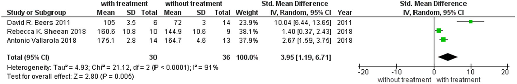

FIGURE 2

Forest plot for analyses of the effect of treatment‐related change in survival. CI, confidence interval; SD, standard deviation

RAJABINEJAD ET AL.

|

5035

1.19–6.71), which favored using Tregs over placebo (statistically

significant difference [p = .005]). In addition, Figure 3 represents a

forest plot for treatment‐related change in the mRNA expression

levels of FOXP3 (data expressed as fold change), which indicates a

standardized mean difference of 3.74 (95% CI: 1.51–5.96), demon-

strating statistically significant difference (p = .001) in the mRNA

expression of FOXP3 after treatment compared with untreated

transgenic mice.

4.2

|

Clinical results

See Figure 4 for a PRISMA flow chart, showing the study selection

process for this review. We identified 29 records (CENTRAL 7,

MEDLINE 4, CINAHL Plus 8, and clinicaltrials.gov 10) and removed

10 duplicate. After screening, we identified one RCT which is

published as an abstract (not containing the outcomes; Bensimon

et al., 2017), three non‐RCTs (Paganoni et al., 2019; Thonhoff et al.,

2018), one of them was a protocol paper, which is why it was counted

in the ongoing studies (Mandrioli et al., 2018), and four ongoing

studies. We excluded 12 studies which were not fulfilled our

inclusion criteria.

4.2.1

|

Randomized clinical trials

Only one study (Bensimon et al., 2017) was fulfilled our selection

criteria for RCTs, which was published as an abstract (not containing the

outcomes; Table 2). This study is a double‐blind, placebo‐controlled,

randomized (12 patients/groups), a parallel‐group study of IL‐2

(1 million international units [MIU] and 2 MIU/days subcutaneous) for

5 days every 4 weeks for 3 cycles. Assessment times were: Before each

cycle, 3 days after Cycle 1 and 3, 3 weeks after 3 cycles, and 3 months

after the last dosing. As mentioned above, a low dose of IL‐2 can induce

Tregs expansion and survival. All 36 randomized participants were alive

at the end of this study, with no drug‐related SAEs reported. Drug‐

related nonserious adverse events were also similar to those reported in

other conditions and were generally mild to moderate and transient.

Compared with placebo, both IL‐2 doses significantly expanded Tregs

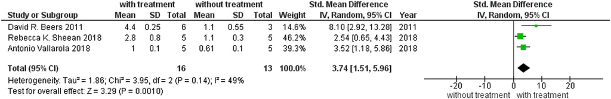

FIGURE 3

Forest plot for analyses of the effect of treatment‐related change in mRNA expression of FOXP3. CI, confidence interval; FOXP3,

forkhead box P3; mRNA, messenger RNA; SD, standard deviation

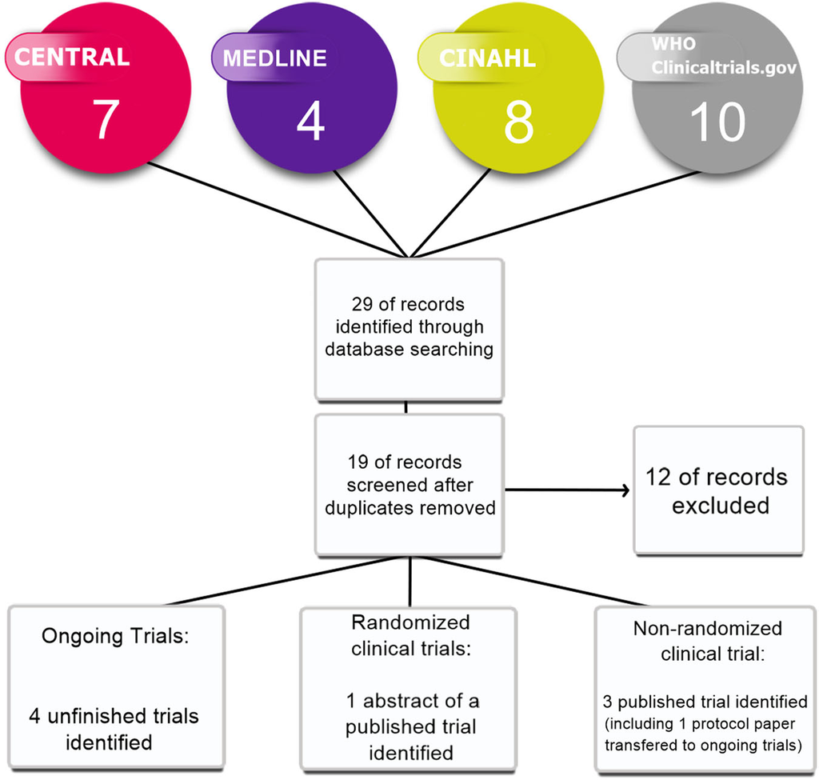

FIGURE 4

Study flow diagram

(PRISMA flow chart) for clinical searches.

CENTRAL, Cochrane Central Register of

Controlled Trials; CINAHL, Cumulative

Index to Nursing and Allied Health

Literature; WHO, World Health

Organization

5036

|

RAJABINEJAD ET AL.

(p < .00001). No significant changes were reported for the ALSFRS and

FVC. The published abstract did not report the evaluation of

proinflammatory or anti‐inflammatory biomarkers.

4.2.2

|

Nonrandomized clinical trials

As previously mentioned, we found three non‐RCTs according to our

inclusion criteria, one of which was excluded from the study because

that was a protocol paper. Characteristics of included non‐RCTs are

shown in (Table 3).

Thonhoff et al’s. (2018) study was a Phase I trial with no placebo

controls and blinding methods. This study was conducted on only

three patients with ALS (with no family history of ALS). For Patient 1,

2, and 3 the score of ALSFRS‐R and the time from symptom onset to

the first Treg infusion (month) were (44, 14), (36, 24), and (41, 38),

respectively. Tregs were isolated and expanded ex vivo with

leukapheresis approximately 1 month before the first injection. In

total, patients were injected eight times intravenously (every 2 weeks

at an early stage and every 4 weeks at a later stage) with expanded

autologous Tregs (1 × 10<sup>6</sup>cells/kg) plus subcutaneously injection of

low dose IL‐2 (2 × 10<sup>5</sup>IU/m<sup>2</sup>) and followed up for almost 2 years.

Treatment with expanded autologous Tregs plus low dose IL‐2, which

was used to stabilize the infused expanded Tregs, increased Tregs

proportion and suppressive function during the first and the second

round of infusions. As well, increased Tregs suppressive function was

associated with decelerated disease progression (correlation for

Patient 1, 2, and 3 was [p = .003], [p = .0026], and [p = .016],

respectively). This study reported no significant changes in FVC

and a slower decrease in ALSFRS‐R score during the first and the

second round of infusions. Moreover, no infusion‐related adverse

events (AEs) were reported (Thonhoff et al., 2018).

Paganoni et al’s. (2019) study was an investigator‐initiated, open‐

label, and pilot clinical trial. In this study, 16 participants with ALS (13

participants completed 23 weeks of treatment) received 375 ml of

RNS60 via intravenous infusion once a week (nebulization at home

the remaining 6 days a week with 4 ml/day). The score of ALSFRS‐R

and the time (month) from symptom onset of participants were

(34.1 ± 6.2) and (30.3 ± 17.8), respectively. As previously mentioned,

RNS60 is an immune modulator agent with a potential for increasing

the Tregs population. After the end of the treatment period, there

were no statistically significant changes in IL‐17 (p = .3) or FOXP3

mRNA expression (p = .9). As outcomes, the most common AEs

included falls (75%), headaches (50%), nasopharyngitis (38%), and

contusions (31%). No serious AEs related to RNS60 occurred and no

participant withdrew from the trial due to treatment‐related AEs.

ALSFRS‐R declined (not statistically significant) over the 23 weeks of

observation and there was no statistically significant change in slow

vital capacity (Paganoni et al., 2019).

4.2.3

|

Ongoing clinical trials

We found four ongoing trials including Mandrioli et al’s. (2018) study

which was a Phase II clinical trial and published as a protocol paper

(not containing the results). Characteristics of ongoing studies are

shown in Table 4.

5

| DISCUSSION AND CONCLUSION

In

this

systematic

review,

we

performed

a

meta‐analysis

to

investigate the efficacy of Tregs (or agents directly targeting them)

in improving survival in preclinical trials, while the number of clinical

TABLE 2

Characteristics of included randomized clinical trial

Study name

Bensimon 2017

Methods

Double‐blind, placebo‐controlled, randomized,

and parallel‐group study

Participants

36 Participants

Interventions

IL‐2 or placebo

Outcomes

Assessment times were: Before each cycle, 3 days

after cycle 1 and 3, 3 weeks after 3 cycles, and 3

months after the last dosing

1. Increase in Tregs proportion

2. No drug‐related SAE

3. No changes in ALSFRS or FVC

Bias

Study findings presented in abstract form but

currently unpublished. The abstract may provide

selective reporting of the results. It is unclear

who was or was not blinded. It is unclear what

information was obtained by which laboratory

methods

GRADE

Moderate quality (⊕⊕⊕O)

Abbreviations: ALS, amyotrophic lateral sclerosis; ALSFRS, ALS functional

rating scale; FVC, forced vital capacity; GRADE, Grading of Recommen-

dations, Assessment, Development, and Evaluation; IL‐2, interleukin‐2;

SAE, serious adverse event; Tregs, regulatory T cells.

TABLE 3

Characteristics of included nonrandomized clinical trials

Study

N

Type

Average

score of

ALSFRS‐R

Average time

from symptom

onset (month)

Treatment‐related

change in Tregs

proportion

Treatment‐

related change in

ALSFRS‐R

Treatment‐

related change

in FVC

SAE

GRADE

Thonhoff et al.

(2018)

3

Phase I

trial

40.33

25.33

Yes

Slower reduction

No

No

Low quality

(⊕⊕OO)

(Not significant)

Paganoni et al.

(2019)

16

Pilot

trial

34.1

30.3

No

Reduction

No

No

Low quality

(⊕⊕OO)

(Not significant)

Abbreviations: ALS, amyotrophic lateral sclerosis; ALSFRS‐R, ALS Functional Rating Scale‐Revised; FVC, forced vital capacity; GRADE, Grading of

Recommendations, Assessment, Development, and Evaluation; SAE, serious adverse event; Tregs, regulatory T cell.

RAJABINEJAD ET AL.

|

5037

trials (randomized and nonrandomized) is still not enough to assess

their exact effectiveness. However, Thonhoff et al’s. (2018) study

showed that the treatment with expanded autologous Tregs plus low

dose IL‐2 can increase Tregs proportion. Furthermore, the suppres-

sive function and increased Tregs function were associated with

decelerated disease progression, which supports the potential of this

approach for the treatment of patients with ALS (Thonhoff et al.,

2018). Nevertheless, due to the low number of participants and the

lack of the control group, there is a potential for publication bias in

this study.

After statistical analysis in preclinical studies (Beers et al., 2011;

Sheean et al., 2018; Vallarola et al., 2018), a significant increase was

observed in the mean difference of the mRNA expression levels of

TABLE 4

Characteristics of ongoing studies

Study ID

NCT02988297

Study name

MIROCALS: Modifying immune response

and outcomes in ALS

Methods

A randomized, placebo‐controlled, double‐

blind, and parallel‐group trial

Participants

216 Participants

Interventions

Treatment arms

• Riluzole

• IL‐2

• Placebo

Outcomes

• Time to death from date of

randomization to date of death

Starting date

June 19, 2017

Contact information

Gilbert Bensimon, Christine Payan

Study ID

NCT02988297

Study name

Nebulized RNS60 for the treatment of

ALS

Methods

A randomized, double‐blind study

Participants

140 Participants

Interventions

Treatment arms

• RNS60

• Placebo

Outcomes

• ALSFRS‐R score

• Deaths or tracheostomies

• The proportion of Treg

• SVC

• ALSAQ‐40 score

• AEs

Starting date

July 2019

Contact information

No contacts or locations provided

Study ID

NCT03359538

Study name

Rapamycin treatment for ALS

Methods

Phase II randomized, double‐blind, placebo‐

controlled, multicenter clinical trial

Participants

63 Participants

Interventions

Treatment arms

• Rapamycin 2 mg/m<sup>2</sup>

• Rapamycin 2 mg/m<sup>2</sup>

• Placebo

Outcomes

• Tregs number

• Number of SAEs and AEs in placebo and

treatment arms

• Rapamycin capacity to pass through the

blood‐brain barrier

• Rapamycin efficacy in inhibiting the

mTOR pathway

• Changes in activation and homing

capabilities of different T, B, natural

killer (NK) cell subpopulations

(Continues)

TABLE 4

(Continued)

Study ID

NCT03359538

• Changes in CSF neurofilaments

• Changes in blood biomarkers

• Rapamycin‐induced changes in

inflammatory status

• ALSFRS‐R

• Tracheostomy‐free survival rate

• Changes in FVC

• Change in quality of life

Starting date

September 19, 2017

Contact information

Jessica Mandrioli

Study ID

NCT03456882

Study name

The effect of RNS60 on ALS biomarkers

Methods

Multicenter, randomized, double‐blind,

placebo‐controlled, parallel group, and

Phase II trial

Participants

142 Participants

Interventions

Treatment arms

• RNS60

• Placebo

Outcomes

• Pharmacodynamics biomarkers, include

Tregs, MCP‐1, and IL‐17

• ALSFRS‐R scale

• Survival

• FVC

• Incidence of adverse event (tolerability)

related to RNS60

• Quality of life

Starting date

November 18, 2016

Contact information

Ettore Beghi, Elisabetta Pupillo

Abbreviations: AEs, adverse events; ALS, amyotrophic lateral sclerosis;

ALSAQ, ALS assessment questionnaire; ALSFRS‐R, ALS functional rating

scale‐revised; CSF, cerebrospinal fluid; FVC, forced vital capacity; IL‐2,

interleukin‐2; IL‐17, interleukin‐17; MCP‐1, monocyte chemoattractant

protein‐1; mTOR, mechanistic target of rapamycin; SAE, serious adverse

event; SVC, slow vital capacity; Tregs, regulatory T cells.

5038

|

RAJABINEJAD ET AL.

Some of these studies also showed an increase in anti‐inflammatory

cytokines and a reduction in inflammatory cytokines after treatment,

which indicates the usefulness of Tregs in treating mice model of ALS.

However, some researchers still have concerns about the general-

ization of the results of preclinical studies into effective human

treatments (Mancuso & Navarro, 2015). This concern could be

acceptable, because transgenic mSOD1<sup>G93A</sup>mice are more likely to

develop familial ALS than sALS. Because ALS is a heterogeneous

disease with little‐known etiopathogenetic implications, it is possible

that familial and sporadic types of disease differ in some important

mechanisms, which makes them different in the effectiveness of

treatments.

In addition, it should be considered in future studies that Tregs

have a heterogeneous phenotype so that only the examination of

mRNA expression of genes (such as FOXP3) is not reliable, and more

precise techniques, such as flow cytometry and more reliable

markers should be exerted. Because there are also FOXP3<sup>−</sup>Tregs

that should be considered in the studies. Another point to be taken

into account in future studies is the time it takes for the drugs to

increase the population of Tregs. Because patients with ALS

generally do not have proper clinical conditions, the time required

for the efficacy of the drug should be taken into account.

In conclusion, ALS is a lethal heterogeneous disease, in which our

knowledge of the causes of its occurrence has not yet been

completed. In addition, the management and treatment of ALS have

not been successful until today. Preclinical studies, as well as some of

the results of clinical studies, indicate the effectiveness of Tregs

application in the treatment of this disease. Tregs can be the future

of ALS therapy. However, more RCTs have to be done to ensure their

effectiveness in the treatment of ALS. Moreover, the results of the

ongoing clinical trials, which have not yet been completed, can largely

contribute to understanding whether the Tregs are beneficial for the

treatment of ALS.

ACKNOWLEDGMENTS

The authors would like to thank the Student Research Committee of

Kermanshah University of Medical Sciences for their kind and

prompt support.

CONFLICT OF INTERESTS

The authors declare that there are no conflict of interests.

AUTHOR CONTRIBUTIONS

M. R. N. and S. R. conceived the study and wrote the manuscript.

They performed the literature search and selected the relevant

studies. F. S. and A. G. K. provided methodological support in the

study design and classified retrieved articles according to the level of

evidence. A. R. and L. A. H. critically revised the manuscript and

provided the final approval.

ORCID

Misagh Rajabinejad

http://orcid.org/0000-0002-1217-2059

Sedigheh Ranjbar

http://orcid.org/0000-0002-1673-8961

Leila Afshar Hezarkhani

http://orcid.org/0000-0003-0244-0379

Farhad Salari

http://orcid.org/0000-0003-3211-0354

Ali Gorgin Karaji

http://orcid.org/0000-0003-4537-5722

Alireza Rezaiemanesh

http://orcid.org/0000-0003-2551-705X

REFERENCES

A McCombe, P., & D Henderson, R. (2011). The role of immune and

inflammatory mechanisms in ALS. Current Molecular Medicine, 11(3),

246–254.

Ajroud‐Driss,

S.,

&

Siddique,

T.

(2015).

Sporadic

and

hereditary

amyotrophic lateral sclerosis (ALS). Biochimica et Biophysica Acta

(BBA)‐Molecular Basis of Disease, 1852(4), 679–684.

Alsuliman, A., Appel, S. H., Beers, D. R., Basar, R., Shaim, H., Kaur, I., …

Rezvani, K. (2016). A robust, good manufacturing practice–compliant,

clinical‐scale procedure to generate regulatory T cells from patients

with amyotrophic lateral sclerosis for adoptive cell therapy. Cytother-

apy, 18(10), 1312–1324.

Azimi, M., Aslani, S., Mortezagholi, S., Salek, A., Javan, M. R., Rezaiema-

nesh, A., … Salehi, E. (2016). Identification, isolation, and functional

assay

of

regulatory

T

cells.

Immunological

Investigations,

45(7),

584–602. https://doi.org/10.1080/08820139.2016.1193869

Bargh, S. R. C., Tafakhori, A., Masoumi, F., Rahmani, F., Ahmadi, M.,

Namdar, A., … Zamani, B. (2018). Evaluation of regulatory T

lymphocytes and IL2Ra and FOXP3 gene expression in peripheral

mononuclear cells from patients with amyotrophic lateral sclerosis.

Irish Journal of Medical Science (1971‐), 1–7.

Beers, D. R., & Appel, S. H. (2019). Immune dysregulation in amyotrophic

lateral sclerosis: Mechanisms and emerging therapies. The Lancet

Neurology, 18(2), 211–220.

Beers, D. R., Henkel, J. S., Zhao, W., Wang, J., Huang, A., Wen, S., … Appel,

S. H. (2011). Endogenous regulatory T lymphocytes ameliorate

amyotrophic lateral sclerosis in mice and correlate with disease

progression in patients with amyotrophic lateral sclerosis. Brain,

134(5), 1293–1314.

Beers, D. R., Zhao, W., Wang, J., Zhang, X., Wen, S., Neal, D., … Rezvani, K.

(2017). ALS patients’ regulatory T lymphocytes are dysfunctional, and

correlate with disease progression rate and severity. JCI Insight, 2(5).

Bensimon, G., Camu, W., Payan, C., Tree, T., Veyrune, J.‐L., Malaspina, A., …

Leigh, P. (2017). Immuno‐modulation in amyotrophic lateral sclerosis

—a phase II study of safety and activity of low dose interleukin‐2

(IMODALS study). Neurology, 88(16 Suppl.), S3.006.

Brooks, B. R. (1994). El escorial World Federation of Neurology criteria

for the diagnosis of amyotrophic lateral sclerosis. Journal of the

Neurological Sciences, 124, 96–107.

Brooks, B. R., Miller, R. G., Swash, M., & Munsat, T. L. (2000). El Escorial

revisited: Revised criteria for the diagnosis of amyotrophic lateral

sclerosis. Amyotrophic Lateral Sclerosis and Other Motor Neuron

Disorders, 1(5), 293–299.

Cedarbaum, J. M., Stambler, N., Malta, E., Fuller, C., Hilt, D., Thurmond, B.,

& Nakanishi, A. (1999). The ALSFRS‐R: A revised ALS functional rating

scale that incorporates assessments of respiratory function. Journal of

the Neurological Sciences, 169(1‐2), 13–21.

Czaplinski, A., Yen, A., & Appel, S. H. (2006). Forced vital capacity (FVC) as

an indicator of survival and disease progression in an ALS clinic

population. Journal of Neurology, Neurosurgery and Psychiatry, 77(3),

390–392.

Henkel, J. S., Beers, D. R., Wen, S., Rivera, A. L., Toennis, K. M., Appel, J. E.,

… Appel, S. H. (2013). Regulatory T‐lymphocytes mediate amyotrophic

RAJABINEJAD ET AL.

|

5039

lateral sclerosis progression and survival. EMBO Molecular Medicine,

5(1), 64–79.

Higgins, J. & Green, S. (Eds.), (2011). Cochrane handbook for systematic

reviews of interventions. Version 5.1.0. Oxford, UK: The Cochrane

Collaboration. www.cochrane‐handbook.org

Lasiene, J., & Yamanaka, K. (2011). Glial cells in amyotrophic lateral

sclerosis. Neurology Research International, 2011, 1–7.

Mancuso, R., & Navarro, X. (2015). Amyotrophic lateral sclerosis: Current

perspectives from basic research to the clinic. Progress in Neurobiology,

133, 1–26.

Mandrioli, J., D’Amico, R., Zucchi, E., Gessani, A., Fini, N., Fasano, A., …

Lunetta, C. (2018). Rapamycin treatment for amyotrophic lateral

sclerosis: Protocol for a phase II randomized, double‐blind, placebo‐

controlled, multicenter, clinical trial (RAP‐ALS trial). Medicine, 97(24)

e11119.

Mateen, F. J., Carone, M., & Sorenson, E. J. (2010). Patients who survive 5

years or more with ALS in Olmsted County, 1925–2004. Journal of

Neurology, Neurosurgery & Psychiatry, 81(10), 1144–1146.

Menon, P., McKay, F., Schibeci, S., Booth, D., Marmash, N., Parnell, G., …

Vucic, S. (2014). Regulatory T cells in amyotrophic lateral sclerosis: A

role for disease modulation? Journal of Clinical Neuroscience, 21(11),

2050.

Mohr, A., Malhotra, R., Mayer, G., Gorochov, G., & Miyara, M. (2018).

Human FOXP3+ T regulatory cell heterogeneity. Clinical & Transla-

tional Immunology, 7(1), 1005.

Moisse, K., & Strong, M. J. (2006). Innate immunity in amyotrophic lateral

sclerosis. Biochimica et Biophysica Acta (BBA)‐Molecular Basis of Disease,

1762(11‐12), 1083–1093.

Nguyen, M. D., D’Aigle, T., Gowing, G., Julien, J.‐P., & Rivest, S. (2004).

Exacerbation of motor neuron disease by chronic stimulation of

innate immunity in a mouse model of amyotrophic lateral sclerosis.

Journal of Neuroscience, 24(6), 1340–1349.

Paganoni, S., Alshikho, M. J., Luppino, S., Chan, J., Pothier, L., Schoenfeld,

D., … Atassi, N. (2019). A pilot trial of RNS60 in amyotrophic lateral

sclerosis. Muscle & Nerve, 59(3), 303–308.

Phani, S., Re, D. B., & Przedborski, S. (2012). The role of the innate immune

system in ALS. Frontiers in Pharmacology, 3, 150.

Puhan, M. A., Schünemann, H. J., Murad, M. H., Li, T., Brignardello‐

Petersen, R., Singh, J. A., … Guyatt, G. H. (2014). A GRADE Working

Group approach for rating the quality of treatment effect estimates

from network meta‐analysis. BMJ, 349, g5630.

Sheean, R. K., McKay, F. C., Cretney, E., Bye, C. R., Perera, N. D.,

Tomas, D., … Turner, B. J. (2018). Association of regulatory T‐cell

expansion with progression of amyotrophic lateral sclerosis: A study

of humans and a transgenic mouse model. JAMA Neurology, 75(6),

681–689.

Simmons, Z., Felgoise, S. H., Rodriguez, J. L., Walsh, S. M., Bremer, B. A., &

Stephens, H. E. (2010). Validation of a shorter ALS‐specific quality of

life instrument: The ALSSQOL‐R. Paper presented at the Neurology.

Talbot, K., Feneberg, E., Scaber, J., Thompson, A. G., & Turner, M. R.

(2018). Amyotrophic lateral sclerosis: The complex path to precision

medicine. Journal of Neurology, 265(10), 2454–2462.

Thonhoff, J. R., Beers, D. R., Zhao, W., Pleitez, M., Simpson, E. P., Berry, J.

D.,

…

Appel,

S.

H.

(2018).

Expanded

autologous

regulatory

T‐lymphocyte infusions in ALS: A phase I, first‐in‐human study.

Neurology‐Neuroimmunology Neuroinflammation, 5(4), e465.

Vallarola, A., Sironi, F., Tortarolo, M., Gatto, N., De Gioia, R., Pasetto, L., …

Watson, R. (2018). RNS60 exerts therapeutic effects in the SOD1 ALS

mouse model through protective glia and peripheral nerve rescue.

Journal of Neuroinflammation, 15(1), 65.

Van Dyke, J. M., Smit‐Oistad, I. M., Macrander, C., Krakora, D., Meyer, M.

G., & Suzuki, M. (2016). Macrophage‐mediated inflammation and glial

response in the skeletal muscle of a rat model of familial amyotrophic

lateral sclerosis (ALS). Experimental Neurology, 277, 275–282.

Zhao, W., Beers, D. R., & Appel, S. H. (2013). Immune‐mediated

mechanisms in the pathoprogression of amyotrophic lateral sclerosis.

Journal of Neuroimmune Pharmacology, 8(4), 888–899.

Zhao, W., Beers, D. R., Liao, B., Henkel, J. S., & Appel, S. H. (2012).

Regulatory T lymphocytes from ALS mice suppress microglia and

effector T lymphocytes through different cytokine‐mediated mechan-

isms. Neurobiology of Disease, 48(3), 418–428. https://doi.org/10.

1016/j.nbd.2012.07.008

Zou, Z.‐Y., Zhou, Z.‐R., Che, C.‐H., Liu, C.‐Y., He, R.‐L., & Huang, H.‐P.

(2017). Genetic epidemiology of amyotrophic lateral sclerosis: A

systematic review and meta‐analysis. Journal of Neurology, Neurosur-

gery and Psychiatry, 88(7), 540–549.

SUPPORTING INFORMATION

Additional supporting information may be found online in the

Supporting Information section.

How to cite this article: Rajabinejad M, Ranjbar S, Afshar

Hezarkhani L, Salari F, Gorgin Karaji A, Rezaiemanesh A.

Regulatory T cells for amyotrophic lateral sclerosis/motor

neuron disease: A clinical and preclinical systematic review.

J Cell Physiol. 2020;235:5030–5040.

https://doi.org/10.1002/jcp.29401

5040

|

RAJABINEJAD ET AL.